# 期中考結果說明

第 1–7 週範圍｜2026-10-29 施測，43 人作答

HT3001B 生物統計學與 R

2026-11-05

## 整體成績：平均 70.7 分，中位數 72 分

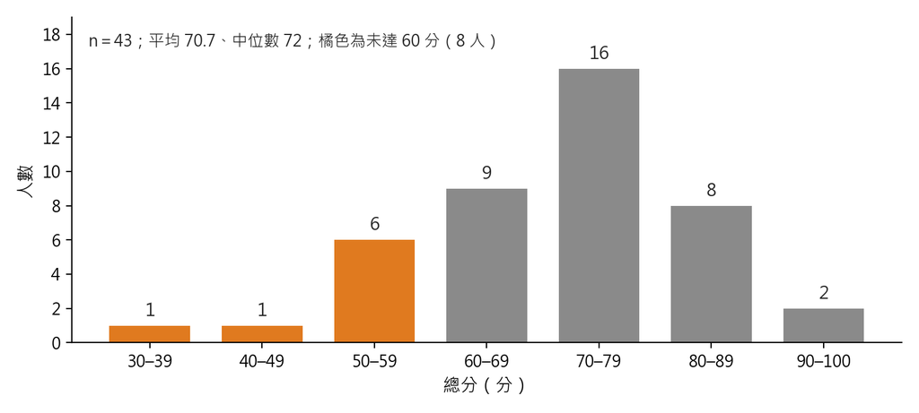

總分分布，每 10 分一組；橘色為未達 60 分的組

| 項目 | 數值 |
| --- | --- |
| 平均數 | 70.7 |
| 標準差 | 12.5 |
| 中位數 | 72 |
| Q1–Q3 | 64–79 |
| 最低–最高 | 39–92 |
| 60 分以上 | 35 人（81%） |

資料：eeClass 選擇題自動計分＋計算簡答題複評後定稿（2026-11-04）

## 選擇題拉開差距，問答題分數較集中

| 部分 | 滿分 | 平均 | 中位數 | 範圍 | 得分率 |
| --- | --- | --- | --- | --- | --- |
| 選擇題 25 題 | 50 | 31.4 | 32 | 14–46 | 63% |
| 計算簡答 5 題 | 50 | 39.3 | 41 | 21–49 | 79% |

- 問答題的判級：計算小題只要選對公式、寫出代入過程就算對，數值小誤差不扣；說明小題講到重點、沒有相反概念就算對。
- 每題的小題得分與評語已在 eeClass 的作答紀錄中。

評分依「期中考計算簡答評分指導」寬鬆版判級

## 選擇題 25 題的答對率

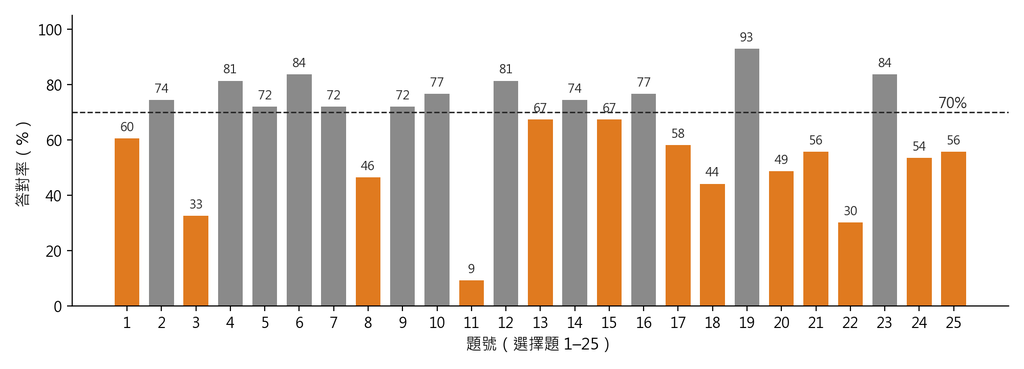

每題答對率；橘色為低於 70% 的 13 題，虛線為 70%

**13 題低於 70%**；第 11 題（比例的常態近似條件）只有 4 人答對。

答對率＝答對人數 ÷ 43

## 問答題 20 個小題的得分率

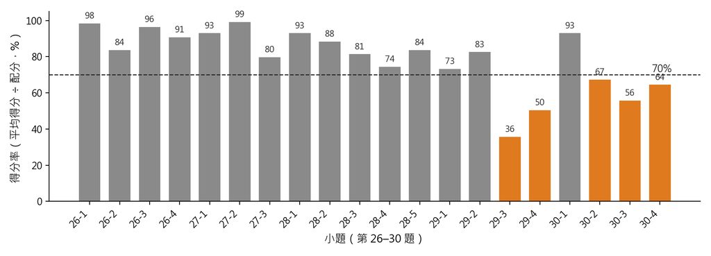

每個小題的得分率；橘色為低於 70% 的 5 個小題

計算類小題多在 80% 以上；**解釋信賴區間、重抽次數與型一錯誤的小題最低**。

得分率＝平均得分 ÷ 配分

## 答對率 70% 以下的題目：共 18 項

[output not shown]

接下來依答對率由低到高逐題說明：左邊是題目，右邊是解說。

## 第 11 題（9%）：事件與非事件都要至少 10 筆

**題目** 四份樣本均滿足獨立性。以 95% 信賴水準、用常態近似建立單一比例的信賴區間，哪一份資料滿足課堂介紹的事件／非事件筆數條件？

1. 120 人；6 件事件
2. 40 人；20 件事件
3. 500 人；495 件事件
4. 100 人；92 件事件

**解說**

- **正解 B**：事件 20、非事件 20，兩類都至少 10 筆。
- 20 人選 A：事件只有 6 筆。
- 13 人選 C：非事件只有 5 筆；D 的非事件也只有 8 筆。
- 樣本大不等於條件成立，要看**人數較少的那一類**是否達到 10 筆。

IMS 2e §16.2；第五週 Part 1

## 第 22 題（30%）：次序資料用 Spearman，並保留同一人的配對

**題目** `health` 有 84 人的 `activity`（自評活動程度 1–5 級，相鄰等級差距不相等）與 `steps`（步數），兩欄各有遺漏。哪段程式最適合計算兩者的相關，並保留同一人的配對？

1. `cor(activity, steps, method = "pearson", use = "complete.obs")`
2. `cor(activity[!is.na(activity)], steps[!is.na(steps)], method = "spearman")`
3. `cor(activity, steps, method = "spearman")`
4. `cor(activity, steps, method = "spearman", use = "complete.obs")`

**解說**

- **正解 D**：次序關聯用 Spearman；`use = "complete.obs"` 只用兩欄都有值的 68 人。
- 15 人選 A：Pearson 假定等級之間的差距相等，不適合次序變項。
- 14 人選 B：兩欄各自刪除遺漏後長度不同（76 與 72），配對被打亂，執行也會報錯。
- C：遇到遺漏值會得到 NA。

Rosner 8e §11.12；R 實習 3

## 第 3 題（33%）：`geom_bar()` 會自己計次

**題目** `visits` 每列是一次門診，`department` 的紀錄筆數依序為 A 科 4 筆、B 科 2 筆、C 科 1 筆；另已執行 `freq <- visits |> count(department)`。哪段程式會產生三根高度依序為 4、2、1 的長條圖？

1. `ggplot(visits, aes(x = department)) + geom_bar()`
2. `ggplot(freq, aes(x = department)) + geom_bar()`
3. `ggplot(freq, aes(x = n)) + geom_bar()`
4. `ggplot(visits, aes(x = department)) + geom_histogram(binwidth = 1)`

**解說**

- **正解 A**：`geom_bar()` 對輸入資料的列數計次，原始列資料得到 4、2、1。
- 23 人選 B：`freq` 每科只有一列，再計次會讓三根都是 1。
- 已經算好的次數要用 `geom_col(aes(x = department, y = n))`。
- D：類別變項不能用直方圖，建立圖時會報錯。

R 實習 2；IMS 2e §4.1

## 第 18 題（44%）：每個門診都納入、各名冊內抽人，是分層抽樣

**題目** 醫院要了解四種門診當月所有成年病人的等候經驗。研究小組沒有先抽選部分門診，而是從每種門診的完整名冊各隨機抽出 100 人；資料表一列代表一位病人。「資料表每列的對象」與「抽樣方式」依序是哪一組？

1. 一種門診；cluster sampling
2. 一位病人；cluster sampling
3. 一種門診；stratified sampling
4. 一位病人；stratified sampling

**解說**

- **正解 D**：每列是一位病人；四種門診全部納入、門診內再抽人，是分層（stratified）。
- 16 人選 B：群聚抽樣（cluster）是先隨機抽「部分門診」，再把抽中門診的全部病人納入；本題沒有抽門診。
- 分辨方式：被隨機挑選的是「群」還是「群內的人」。

IMS 2e §2.1

**題目** 假設某連續量測值的 Z 分數服從標準常態分布。已知 z＝1 處的曲線高度約為 0.2420，而 1 左側的曲線下面積約為 0.8413。P(Z＝1) 與 P(Z≤1) 依序為何？

1. 0.2420；0.8413
2. 0.8413；0.2420
3. 0；0.2420
4. 0；0.8413

**解說**

- **正解 D**：單一點沒有寬度，面積為 0；P(Z≤1) 是 1 左側的累積面積 0.8413。
- 21 人選 A：把曲線高度當成單點機率。曲線高度是**密度**，機率是曲線下的**面積**。
- C 把密度當成累積機率，B 把高度與面積對調。

IMS 2e §13.1

## 第 20 題（49%）：右偏、少數極端值，用中位數配 IQR

**題目** 問卷回覆者的等候時間明顯右偏，少數人等候特別久，且都是實際紀錄。團隊要用兩個數值，分別摘要回覆者的典型等候時間與散布，並降低少數極長等候紀錄的影響。最適當的組合是什麼？

1. Median；interquartile range
2. Mean；interquartile range
3. Median；standard deviation
4. Mean；standard deviation

**解說**

- **正解 A**：中位數與四分位距都不受少數極端值影響。
- 10 人選 B：平均數會被極長的等候時間拉高。
- 9 人選 C：標準差同樣受極端值影響。
- 這不表示右偏資料一律不能報平均數，而是題目要求「降低極端值的影響」。

IMS 2e §5.5–5.6

## 第 24 題（54%）：殘差中心彎曲是線性的警訊，散布一致則沒有等變異警訊

**題目** 以步數預測心率的簡單線性迴歸，依預測值分成三個人數相同的區段：

| 區段 | 人數 | 殘差平均 | 殘差 SD |
| --- | --- | --- | --- |
| 低 | 24 | −2 | 3 |
| 中 | 24 | 4 | 3 |
| 高 | 24 | −2 | 3 |

結合三個區段的殘差中心與散布，哪項判斷最符合表中訊息？

1. 線性與等變異皆無明顯警訊
2. 僅等變異有明顯警訊
3. 僅線性有明顯警訊
4. 線性與等變異皆有明顯警訊

**解說**

- **正解 C**：殘差中心隨預測值先低、再高、再低，是直線沒有描述到的彎曲。
- 三段標準差相同，沒有散布改變的訊號；8 人選 B、7 人選 D 把它也當成警訊。
- 表中資訊不能用來「證明」等變異成立，也不能檢查獨立或常態。

IMS 2e §7.3、§24.6

## 第 21 題（56%）：回覆率不同的兩類人，只用回覆者會高估

**題目** 行政紀錄顯示目標母體中至少等候 40 分鐘者占 25%。受邀 400 人中，至少等候 40 分鐘者 100 人、回覆 80 人；少於 40 分鐘者 300 人、回覆 160 人。若將來繼續增加邀請人數，兩類的比例與回覆機率維持不變，只用回覆者估計「至少等候 40 分鐘的比例」，相對目標母體最可能出現何種偏差？

1. Downward bias
2. No bias
3. Upward bias
4. Cannot determine

**解說**

- **正解 C**：回覆者裡長等候者占 80／240＝33%，高於母體的 25%，向上偏誤。
- 長等候者的回覆率 80%，短等候者 53%；較願意回覆的那一類在回覆者中被放大。
- 11 人選 A：方向相反。
- 增加邀請人數不會消除無回應偏差，因為兩類人的回覆率仍然不同。

IMS 2e §2.1

## 第 25 題（56%）：事前指定雙尾，p 值是兩尾相加

**題目** 檢定母體皮爾森相關係數是否為 0。模擬得到的虛無分布中，P(T≤−0.21)＝0.038、P(T≥0.21)＝0.041；觀察值 T＝−0.21，事前規定以 |T| 越大視為越極端。依事前指定的雙尾規則，p 值應為多少？

1. 0.079
2. 0.038
3. 0.076
4. 0.041

**解說**

- **正解 A**：0.038＋0.041＝0.079，兩尾實際的機率相加。
- 9 人選 B：只取觀察到的那一尾。
- 7 人選 C：把一尾乘以 2，等於假定模擬分布左右對稱；實際模擬得到的兩尾並不相等。
- D 取的是另一尾。

IMS 2e §11.3、§14.1

## 第 17 題（58%）：統計顯著與實際重要是兩件事

**題目** 兩項研究皆預設 α＝0.05，並以差異至少 5 分為實際重要性門檻。

| 研究 | 兩組平均數差的點估計 | p 值 |
| --- | --- | --- |
| 甲 | 0.1 分 | 0.001 |
| 乙 | 6.0 分 | 0.20 |

「達統計顯著」與「點估計達實際重要性門檻」依序是哪項研究？

1. 甲；甲
2. 甲；乙
3. 乙；乙
4. 乙；甲

**解說**

- **正解 B**：達顯著的是甲（p＜0.05）；點估計達門檻的是乙（6.0 分≥5 分）。
- 10 人選 C：乙的 p＝0.20 沒有達到顯著。
- p 值小不代表效果大；點估計超過門檻也不能證明母體差異已超過 5 分。

IMS 2e Ch. 14；第七週 Part 2

## 第 1 題（60%）：改碼保持順序，中位數所在的等級不變

**題目** 某次序類別變項有 101 筆資料，四個等級皆有觀察值；原編碼 0、1、2、3 依序改為 0、1、4、9。下列哪項必然不變？

1. Value of the maximum
2. Value of the mean
3. Value of the standard deviation
4. Category containing the median

**解說**

- **正解 D**：改碼沒有改變排序，中位數落在同一個等級。
- 14 人選 C：標準差用到數值之間的差距，改碼後會改變；平均數與最大值的數值也會改變。
- 「中位數所屬等級不變」不等於「中位數的編碼數值不變」。

IMS 2e §1.2、§5.3

## 第 13 題（67%）：已知 σ 的方法，要的是母體標準差真的已知

**題目** 甲資料有 500 人，只知道樣本標準差 s＝8；乙資料有 36 人，且母體標準差確實已知為 σ＝8。兩者皆滿足獨立性，平均數的常態模型亦適用。哪一份可直接使用課堂的已知母體標準差方法？

1. 僅乙
2. 僅甲
3. 甲、乙皆可
4. 甲、乙皆不可

**解說**

- **正解 A**：只有乙的 σ 是已知的。
- 7 人選 C：甲的 n 很大，但 8 只是樣本標準差 s，σ 仍是估計出來的，不符合「已知」。
- 樣本大小不會把樣本標準差變成母體標準差。

第五週 Part 1；IMS 2e §13.3

## 第 15 題（67%）：有效筆數要算「不是 NA」的，0 也算有效

**題目** `scores` 中，A 組的 `score` 為 0、5、NA，B 組為 10、NA、NA。要各組一列，且 `valid_n` 分別為 A 組 2、B 組 1，應選哪段程式（皆接在 `scores |> group_by(group) |>` 之後）？

1. `summarise(valid_n = sum(!is.na(score)))`
2. `summarise(valid_n = sum(score > 0, na.rm = TRUE))`
3. `summarise(valid_n = sum(is.na(score)))`
4. `summarise(valid_n = n())`

**解說**

- **正解 A**：`!is.na(score)` 把 0 算進有效值、把 NA 排除，得到 2 與 1。
- 12 人選 B：只算正值，A 組的 0 被排除，得到 1。
- C 算的是遺漏筆數（1、2）；D 的 `n()` 算全部列數（3、3）。

R 實習 2

## 29-3（36%）：區間估計的是母體中位數，95% 說的是程序的涵蓋率

**題目** 從目標母體隨機取得 80 位互相獨立的服務使用者，各記錄一次等候時間；對樣本做 4,000 次 bootstrap 中位數，百分位法得到中央 95% 區間 [8.4, 17.2] 分鐘。

第 3 小題：解釋 95% 區間所估計的母體量，以及 95% 信賴水準的意思。（3 分）

**解說**

- 估計對象是目標母體等候時間的**中位數**。
- 95% 的意思：反覆抽取同樣大小的樣本、用同樣程序建構區間，約 95% 的區間會涵蓋這個固定的母體中位數。
- 常見寫法：「95% 的使用者等候 8.4–17.2 分鐘」（區間不描述個人）、「母體量是 80 人」（問的是參數，不是人數）、「母體中位數有 95% 的機率落在區間內」（機率是對程序說的）。

IMS 2e §12.3–12.4、§13.6

## 29-4（50%）：重抽次數 B 只減少模擬誤差，區間寬度由原始樣本數決定

**題目** 同上題的 bootstrap（n＝80，重抽 4,000 次）。

第 4 小題：有人建議「把重抽次數從 4,000 次增加到 40,000 次，區間就會明顯變窄、估計更精確」。增加重抽次數主要改善什麼？95% 區間會因此大致減半嗎？請說明理由。（3 分）

**解說**

- 增加 B 只讓 bootstrap 分布與百分位端點更穩定（減少模擬誤差），不會增加關於母體的資訊。
- 區間寬度主要由原始樣本數 n＝80 與資料本身的變異決定，不會因此減半；要讓寬度減半，樣本數要變成 4 倍。
- 常見寫法：「B 變大，標準誤變小，區間變窄」，這把重抽次數 B 當成了樣本數 n。

IMS 2e §12.1–12.2

## 30-2 與 30-3（67%、56%）：算出 z 之後要寫決策；門檻用 SE，不用 σ

**題目** n＝100、x̄＝53 分、母體標準差 σ＝12 分已知；H₀: μ≤50、H₁: μ＞50，右尾檢定，α＝0.05，臨界值 1.645。已給中間結果：√100＝10、53−50＝3、1.645×12＝19.74。

第 2 小題：計算 z 統計量，並用臨界值作統計決策，寫出比較過程。（2 分）

第 3 小題：將 z 臨界值換回分數尺度求 x̄crit，並寫出樣本平均須落在門檻的哪一側才拒絕 H₀。（2 分）

**解說**

- 30-2：SE＝12/10＝1.2，z＝3/1.2＝2.5。完整的作答要接著寫「2.5＞1.645，拒絕 H₀」；只算到 2.5 沒有回答決策。
- 30-3：x̄crit＝50＋1.645×SE＝50＋1.645×1.2≈51.97 分；樣本平均高於它才拒絕 H₀。
- 10 人用了題目給的 19.74（＝1.645×σ）得到 69.74。門檻說的是樣本平均數的分布，要乘的是 SE＝σ/√n，19.74 是刻意放的錯誤組合。

IMS 2e §13.3、§14.1

**題目** 同上題：H₀: μ≤50 分，檢定結果拒絕 H₀。

第 4 小題：(a) 若這次的統計決策其實是型一錯誤，目標母體的實際狀況是什麼？(b) 拒絕 H₀ 是否表示每位受測者的分數都高於 50 分？請說明理由。（4 分）

**解說**

- 1. 母體的實際狀況是**平均分數不高於 50 分**（H₀ 為真），卻被拒絕了。常見錯誤：寫成「母體平均其實大於 50」，或寫成未拒絕 H₀ 的情形（那是型二錯誤）。
- 2. 不表示。拒絕 H₀ 只說明有證據支持**母體平均**高於 50 分；個人分數仍有散布（母體 SD 為 12 分），可能有不少人低於 50 分。

IMS 2e §14.1–14.3

## 之後怎麼用這份結果

- eeClass 的作答紀錄裡，每一題有分數與評語；問答題的評語最後一行列出各小題得分。
- 複習方向：抽樣與偏差（IMS Ch. 2）、信賴區間與檢定的解釋（Ch. 12–14）、R 的計次與遺漏處理（R 實習 2–3）。
- 對分數有疑問，先看該題評語，再於課堂或 e-mail 提出。

成績以 eeClass 紀錄為準